# Cyclistic Case Study

Dwayne Marson

```r
setwd("~/DataAnalyticsCapstone/")
```

### **Cyclistic Bikeshare Analysis**

#### **An optional project done as part of the Google Dta Analytics Certificate course.**

#### **Preparing the Environment**

```r
# Loading the tools needed for the analysis

library(tidyverse) # For data manipulation and plotting
library(readr) # For reading dataset into the environment
library(dplyr)
library(lubridate) # For handling dates and time
library(janitor) # For cleaning column names
library(ggplot2)
library(scales)
library(knitr)
```

### **2. Preparing The Data for Processing**

Imported all datasets and renamed them for better workflow.

```r
# Import all Datasets

df_202404_tripdata <- read_csv("data/202404-divvy-tripdata.csv")
df_202405_tripdata <- read_csv("data/202405-divvy-tripdata.csv")
df_202406_tripdata <- read_csv("data/202406-divvy-tripdata.csv")
df_202407_tripdata <- read_csv("data/202407-divvy-tripdata.csv")
df_202408_tripdata <- read_csv("data/202408-divvy-tripdata.csv")
df_202409_tripdata <- read_csv("data/202409-divvy-tripdata.csv")
df_202410_tripdata <- read_csv("data/202410-divvy-tripdata.csv")
df_202411_tripdata <- read_csv("data/202411-divvy-tripdata.csv")
df_202412_tripdata <- read_csv("data/202412-divvy-tripdata.csv")
df_202501_tripdata <- read_csv("data/202501-divvy-tripdata.csv")
df_202502_tripdata <- read_csv("data/202502-divvy-tripdata.csv")
df_202503_tripdata <- read_csv("data/202503-divvy-tripdata.csv")
```

#### **Inspecting table structures**

```r
# Comparing the columns in each of the files

colnames(df_202404_tripdata)
```

```
##  [1] "ride_id"            "rideable_type"      "started_at"
##  [4] "ended_at"           "start_station_name" "start_station_id"
##  [7] "end_station_name"   "end_station_id"     "start_lat"
## [10] "start_lng"          "end_lat"            "end_lng"
## [13] "member_casual"
```

```r
colnames(df_202405_tripdata)
```

```
##  [1] "ride_id"            "rideable_type"      "started_at"
##  [4] "ended_at"           "start_station_name" "start_station_id"
##  [7] "end_station_name"   "end_station_id"     "start_lat"
## [10] "start_lng"          "end_lat"            "end_lng"
## [13] "member_casual"
```

```r
colnames(df_202406_tripdata)
```

```
##  [1] "ride_id"            "rideable_type"      "started_at"
##  [4] "ended_at"           "start_station_name" "start_station_id"
##  [7] "end_station_name"   "end_station_id"     "start_lat"
## [10] "start_lng"          "end_lat"            "end_lng"
## [13] "member_casual"
```

```r
colnames(df_202407_tripdata)
```

```
##  [1] "ride_id"            "rideable_type"      "started_at"
##  [4] "ended_at"           "start_station_name" "start_station_id"
##  [7] "end_station_name"   "end_station_id"     "start_lat"
## [10] "start_lng"          "end_lat"            "end_lng"
## [13] "member_casual"
```

```r
colnames(df_202408_tripdata)
```

```
##  [1] "ride_id"            "rideable_type"      "started_at"
##  [4] "ended_at"           "start_station_name" "start_station_id"
##  [7] "end_station_name"   "end_station_id"     "start_lat"
## [10] "start_lng"          "end_lat"            "end_lng"
## [13] "member_casual"
```

```r
colnames(df_202409_tripdata)
```

```
##  [1] "ride_id"            "rideable_type"      "started_at"
##  [4] "ended_at"           "start_station_name" "start_station_id"
##  [7] "end_station_name"   "end_station_id"     "start_lat"
## [10] "start_lng"          "end_lat"            "end_lng"
## [13] "member_casual"
```

```r
colnames(df_202410_tripdata)
```

```
##  [1] "ride_id"            "rideable_type"      "started_at"
##  [4] "ended_at"           "start_station_name" "start_station_id"
##  [7] "end_station_name"   "end_station_id"     "start_lat"
## [10] "start_lng"          "end_lat"            "end_lng"
## [13] "member_casual"
```

```r
colnames(df_202411_tripdata)
```

```
##  [1] "ride_id"            "rideable_type"      "started_at"
##  [4] "ended_at"           "start_station_name" "start_station_id"
##  [7] "end_station_name"   "end_station_id"     "start_lat"
## [10] "start_lng"          "end_lat"            "end_lng"
## [13] "member_casual"
```

```r
colnames(df_202412_tripdata)
```

```
##  [1] "ride_id"            "rideable_type"      "started_at"
##  [4] "ended_at"           "start_station_name" "start_station_id"
##  [7] "end_station_name"   "end_station_id"     "start_lat"
## [10] "start_lng"          "end_lat"            "end_lng"
## [13] "member_casual"
```

```r
colnames(df_202501_tripdata)
```

```
##  [1] "ride_id"            "rideable_type"      "started_at"
##  [4] "ended_at"           "start_station_name" "start_station_id"
##  [7] "end_station_name"   "end_station_id"     "start_lat"
## [10] "start_lng"          "end_lat"            "end_lng"
## [13] "member_casual"
```

```r
colnames(df_202502_tripdata)
```

```
##  [1] "ride_id"            "rideable_type"      "started_at"
##  [4] "ended_at"           "start_station_name" "start_station_id"
##  [7] "end_station_name"   "end_station_id"     "start_lat"
## [10] "start_lng"          "end_lat"            "end_lng"
## [13] "member_casual"
```

```r
colnames(df_202503_tripdata)
```

```
##  [1] "ride_id"            "rideable_type"      "started_at"
##  [4] "ended_at"           "start_station_name" "start_station_id"
##  [7] "end_station_name"   "end_station_id"     "start_lat"
## [10] "start_lng"          "end_lat"            "end_lng"
## [13] "member_casual"
```

```r
# Take a look at the structure of each table, taking note of the data type in each column

str(df_202404_tripdata)
```

```
## spc_tbl_ [415,025 × 13] (S3: spec_tbl_df/tbl_df/tbl/data.frame)
##  $ ride_id           : chr [1:415025] "743252713F32516B" "BE90D33D2240C614" "D47BBDDE7C40DD61" "6684E760BF9EA9B5" ...
##  $ rideable_type     : chr [1:415025] "classic_bike" "electric_bike" "classic_bike" "classic_bike" ...
##  $ started_at        : POSIXct[1:415025], format: "2024-04-22 19:08:21" "2024-04-11 06:19:24" ...
##  $ ended_at          : POSIXct[1:415025], format: "2024-04-22 19:12:56" "2024-04-11 06:22:21" ...
##  $ start_station_name: chr [1:415025] "Aberdeen St & Jackson Blvd" "Aberdeen St & Jackson Blvd" "Sheridan Rd & Montrose Ave" "Aberdeen St & Jackson Blvd" ...
##  $ start_station_id  : chr [1:415025] "13157" "13157" "TA1307000107" "13157" ...
##  $ end_station_name  : chr [1:415025] "Desplaines St & Jackson Blvd" "Desplaines St & Jackson Blvd" "Ashland Ave & Belle Plaine Ave" "Desplaines St & Jackson Blvd" ...
##  $ end_station_id    : chr [1:415025] "15539" "15539" "13249" "15539" ...
##  $ start_lat         : num [1:415025] 41.9 41.9 42 41.9 42 ...
##  $ start_lng         : num [1:415025] -87.7 -87.7 -87.7 -87.7 -87.7 ...
##  $ end_lat           : num [1:415025] 41.9 41.9 42 41.9 41.9 ...
##  $ end_lng           : num [1:415025] -87.6 -87.6 -87.7 -87.6 -87.6 ...
##  $ member_casual     : chr [1:415025] "member" "member" "member" "member" ...
##  - attr(*, "spec")=
##   .. cols(
##   ..   ride_id = col_character(),
##   ..   rideable_type = col_character(),
##   ..   started_at = col_datetime(format = ""),
##   ..   ended_at = col_datetime(format = ""),
##   ..   start_station_name = col_character(),
##   ..   start_station_id = col_character(),
##   ..   end_station_name = col_character(),
##   ..   end_station_id = col_character(),
##   ..   start_lat = col_double(),
##   ..   start_lng = col_double(),
##   ..   end_lat = col_double(),
##   ..   end_lng = col_double(),
##   ..   member_casual = col_character()
##   .. )
##  - attr(*, "problems")=<externalptr>
```

```r
str(df_202405_tripdata)
```

```
## spc_tbl_ [609,493 × 13] (S3: spec_tbl_df/tbl_df/tbl/data.frame)
##  $ ride_id           : chr [1:609493] "7D9F0CE9EC2A1297" "02EC47687411416F" "101370FB2D3402BE" "E97E396331ED6913" ...
##  $ rideable_type     : chr [1:609493] "classic_bike" "classic_bike" "classic_bike" "electric_bike" ...
##  $ started_at        : POSIXct[1:609493], format: "2024-05-25 15:52:42" "2024-05-14 15:11:51" ...
##  $ ended_at          : POSIXct[1:609493], format: "2024-05-25 16:11:50" "2024-05-14 15:22:00" ...
##  $ start_station_name: chr [1:609493] "Streeter Dr & Grand Ave" "Sheridan Rd & Greenleaf Ave" "Streeter Dr & Grand Ave" "Streeter Dr & Grand Ave" ...
##  $ start_station_id  : chr [1:609493] "13022" "KA1504000159" "13022" "13022" ...
##  $ end_station_name  : chr [1:609493] "Clark St & Elm St" "Sheridan Rd & Loyola Ave" "Wabash Ave & 9th St" "Sheffield Ave & Wellington Ave" ...
##  $ end_station_id    : chr [1:609493] "TA1307000039" "RP-009" "TA1309000010" "TA1307000052" ...
##  $ start_lat         : num [1:609493] 41.9 42 41.9 41.9 41.9 ...
##  $ start_lng         : num [1:609493] -87.6 -87.7 -87.6 -87.6 -87.6 ...
##  $ end_lat           : num [1:609493] 41.9 42 41.9 41.9 41.9 ...
##  $ end_lng           : num [1:609493] -87.6 -87.7 -87.6 -87.7 -87.6 ...
##  $ member_casual     : chr [1:609493] "casual" "casual" "member" "member" ...
##  - attr(*, "spec")=
##   .. cols(
##   ..   ride_id = col_character(),
##   ..   rideable_type = col_character(),
##   ..   started_at = col_datetime(format = ""),
##   ..   ended_at = col_datetime(format = ""),
##   ..   start_station_name = col_character(),
##   ..   start_station_id = col_character(),
##   ..   end_station_name = col_character(),
##   ..   end_station_id = col_character(),
##   ..   start_lat = col_double(),
##   ..   start_lng = col_double(),
##   ..   end_lat = col_double(),
##   ..   end_lng = col_double(),
##   ..   member_casual = col_character()
##   .. )
##  - attr(*, "problems")=<externalptr>
```

```r
str(df_202406_tripdata)
```

```
## spc_tbl_ [710,721 × 13] (S3: spec_tbl_df/tbl_df/tbl/data.frame)
##  $ ride_id           : chr [1:710721] "CDE6023BE6B11D2F" "462B48CD292B6A18" "9CFB6A858D23ABF7" "6365EFEB64231153" ...
##  $ rideable_type     : chr [1:710721] "electric_bike" "electric_bike" "electric_bike" "electric_bike" ...
##  $ started_at        : POSIXct[1:710721], format: "2024-06-11 17:20:06" "2024-06-11 17:19:21" ...
##  $ ended_at          : POSIXct[1:710721], format: "2024-06-11 17:21:39" "2024-06-11 17:19:36" ...
##  $ start_station_name: chr [1:710721] NA NA NA NA ...
##  $ start_station_id  : chr [1:710721] NA NA NA NA ...
##  $ end_station_name  : chr [1:710721] NA NA NA NA ...
##  $ end_station_id    : chr [1:710721] NA NA NA NA ...
##  $ start_lat         : num [1:710721] 41.9 41.9 41.9 41.9 41.9 ...
##  $ start_lng         : num [1:710721] -87.7 -87.7 -87.7 -87.6 -87.6 ...
##  $ end_lat           : num [1:710721] 41.9 41.9 41.9 41.9 41.9 ...
##  $ end_lng           : num [1:710721] -87.7 -87.7 -87.7 -87.6 -87.6 ...
##  $ member_casual     : chr [1:710721] "casual" "casual" "casual" "casual" ...
##  - attr(*, "spec")=
##   .. cols(
##   ..   ride_id = col_character(),
##   ..   rideable_type = col_character(),
##   ..   started_at = col_datetime(format = ""),
##   ..   ended_at = col_datetime(format = ""),
##   ..   start_station_name = col_character(),
##   ..   start_station_id = col_character(),
##   ..   end_station_name = col_character(),
##   ..   end_station_id = col_character(),
##   ..   start_lat = col_double(),
##   ..   start_lng = col_double(),
##   ..   end_lat = col_double(),
##   ..   end_lng = col_double(),
##   ..   member_casual = col_character()
##   .. )
##  - attr(*, "problems")=<externalptr>
```

```r
str(df_202407_tripdata)
```

```
## spc_tbl_ [748,962 × 13] (S3: spec_tbl_df/tbl_df/tbl/data.frame)
##  $ ride_id           : chr [1:748962] "2658E319B13141F9" "B2176315168A47CE" "C2A9D33DF7EBB422" "8BFEA406DF01D8AD" ...
##  $ rideable_type     : chr [1:748962] "electric_bike" "electric_bike" "electric_bike" "electric_bike" ...
##  $ started_at        : POSIXct[1:748962], format: "2024-07-11 08:15:14" "2024-07-11 15:45:07" ...
##  $ ended_at          : POSIXct[1:748962], format: "2024-07-11 08:17:56" "2024-07-11 16:06:04" ...
##  $ start_station_name: chr [1:748962] NA NA NA NA ...
##  $ start_station_id  : chr [1:748962] NA NA NA NA ...
##  $ end_station_name  : chr [1:748962] NA NA NA NA ...
##  $ end_station_id    : chr [1:748962] NA NA NA NA ...
##  $ start_lat         : num [1:748962] 41.8 41.8 41.8 41.9 42 ...
##  $ start_lng         : num [1:748962] -87.6 -87.6 -87.6 -87.6 -87.6 ...
##  $ end_lat           : num [1:748962] 41.8 41.8 41.8 41.9 41.9 ...
##  $ end_lng           : num [1:748962] -87.6 -87.6 -87.6 -87.7 -87.6 ...
##  $ member_casual     : chr [1:748962] "casual" "casual" "casual" "casual" ...
##  - attr(*, "spec")=
##   .. cols(
##   ..   ride_id = col_character(),
##   ..   rideable_type = col_character(),
##   ..   started_at = col_datetime(format = ""),
##   ..   ended_at = col_datetime(format = ""),
##   ..   start_station_name = col_character(),
##   ..   start_station_id = col_character(),
##   ..   end_station_name = col_character(),
##   ..   end_station_id = col_character(),
##   ..   start_lat = col_double(),
##   ..   start_lng = col_double(),
##   ..   end_lat = col_double(),
##   ..   end_lng = col_double(),
##   ..   member_casual = col_character()
##   .. )
##  - attr(*, "problems")=<externalptr>
```

```r
str(df_202408_tripdata)
```

```
## spc_tbl_ [755,639 × 13] (S3: spec_tbl_df/tbl_df/tbl/data.frame)
##  $ ride_id           : chr [1:755639] "BAA154388A869E64" "8752245932EFF67A" "44DDF9F57A9A161F" "44AAAF069B0C78C3" ...
##  $ rideable_type     : chr [1:755639] "classic_bike" "electric_bike" "classic_bike" "electric_bike" ...
##  $ started_at        : POSIXct[1:755639], format: "2024-08-02 13:35:14" "2024-08-02 15:33:13" ...
##  $ ended_at          : POSIXct[1:755639], format: "2024-08-02 13:48:24" "2024-08-02 15:55:23" ...
##  $ start_station_name: chr [1:755639] "State St & Randolph St" "Franklin St & Monroe St" "Franklin St & Monroe St" "Clark St & Elm St" ...
##  $ start_station_id  : chr [1:755639] "TA1305000029" "TA1309000007" "TA1309000007" "TA1307000039" ...
##  $ end_station_name  : chr [1:755639] "Wabash Ave & 9th St" "Damen Ave & Cortland St" "Clark St & Elm St" "McClurg Ct & Ohio St" ...
##  $ end_station_id    : chr [1:755639] "TA1309000010" "13133" "TA1307000039" "TA1306000029" ...
##  $ start_lat         : num [1:755639] 41.9 41.9 41.9 41.9 42 ...
##  $ start_lng         : num [1:755639] -87.6 -87.6 -87.6 -87.6 -87.7 ...
##  $ end_lat           : num [1:755639] 41.9 41.9 41.9 41.9 42 ...
##  $ end_lng           : num [1:755639] -87.6 -87.7 -87.6 -87.6 -87.7 ...
##  $ member_casual     : chr [1:755639] "member" "member" "member" "member" ...
##  - attr(*, "spec")=
##   .. cols(
##   ..   ride_id = col_character(),
##   ..   rideable_type = col_character(),
##   ..   started_at = col_datetime(format = ""),
##   ..   ended_at = col_datetime(format = ""),
##   ..   start_station_name = col_character(),
##   ..   start_station_id = col_character(),
##   ..   end_station_name = col_character(),
##   ..   end_station_id = col_character(),
##   ..   start_lat = col_double(),
##   ..   start_lng = col_double(),
##   ..   end_lat = col_double(),
##   ..   end_lng = col_double(),
##   ..   member_casual = col_character()
##   .. )
##  - attr(*, "problems")=<externalptr>
```

```r
str(df_202409_tripdata)
```

```
## spc_tbl_ [821,276 × 13] (S3: spec_tbl_df/tbl_df/tbl/data.frame)
##  $ ride_id           : chr [1:821276] "31D38723D5A8665A" "67CB39987F4E895B" "DA61204FD26EC681" "06F160D46AF235DD" ...
##  $ rideable_type     : chr [1:821276] "electric_bike" "electric_bike" "electric_bike" "electric_bike" ...
##  $ started_at        : POSIXct[1:821276], format: "2024-09-26 15:30:58" "2024-09-26 15:31:32" ...
##  $ ended_at          : POSIXct[1:821276], format: "2024-09-26 15:30:59" "2024-09-26 15:53:13" ...
##  $ start_station_name: chr [1:821276] NA NA NA NA ...
##  $ start_station_id  : chr [1:821276] NA NA NA NA ...
##  $ end_station_name  : chr [1:821276] NA NA NA NA ...
##  $ end_station_id    : chr [1:821276] NA NA NA NA ...
##  $ start_lat         : num [1:821276] 41.9 41.9 41.9 41.9 41.9 ...
##  $ start_lng         : num [1:821276] -87.6 -87.6 -87.6 -87.6 -87.7 ...
##  $ end_lat           : num [1:821276] 41.9 41.9 41.9 41.9 41.9 ...
##  $ end_lng           : num [1:821276] -87.6 -87.6 -87.6 -87.6 -87.6 ...
##  $ member_casual     : chr [1:821276] "member" "member" "member" "member" ...
##  - attr(*, "spec")=
##   .. cols(
##   ..   ride_id = col_character(),
##   ..   rideable_type = col_character(),
##   ..   started_at = col_datetime(format = ""),
##   ..   ended_at = col_datetime(format = ""),
##   ..   start_station_name = col_character(),
##   ..   start_station_id = col_character(),
##   ..   end_station_name = col_character(),
##   ..   end_station_id = col_character(),
##   ..   start_lat = col_double(),
##   ..   start_lng = col_double(),
##   ..   end_lat = col_double(),
##   ..   end_lng = col_double(),
##   ..   member_casual = col_character()
##   .. )
##  - attr(*, "problems")=<externalptr>
```

```r
str(df_202410_tripdata)
```

```
## spc_tbl_ [616,281 × 13] (S3: spec_tbl_df/tbl_df/tbl/data.frame)
##  $ ride_id           : chr [1:616281] "4422E707103AA4FF" "19DB722B44CBE82F" "20AE2509FD68C939" "D0F17580AB9515A9" ...
##  $ rideable_type     : chr [1:616281] "electric_bike" "electric_bike" "electric_bike" "electric_bike" ...
##  $ started_at        : POSIXct[1:616281], format: "2024-10-14 03:26:04" "2024-10-13 19:33:38" ...
##  $ ended_at          : POSIXct[1:616281], format: "2024-10-14 03:32:56" "2024-10-13 19:39:04" ...
##  $ start_station_name: chr [1:616281] NA NA NA NA ...
##  $ start_station_id  : chr [1:616281] NA NA NA NA ...
##  $ end_station_name  : chr [1:616281] NA NA NA NA ...
##  $ end_station_id    : chr [1:616281] NA NA NA NA ...
##  $ start_lat         : num [1:616281] 42 42 42 42 42 ...
##  $ start_lng         : num [1:616281] -87.7 -87.7 -87.7 -87.7 -87.7 ...
##  $ end_lat           : num [1:616281] 42 42 42 42 42 ...
##  $ end_lng           : num [1:616281] -87.7 -87.7 -87.7 -87.7 -87.7 ...
##  $ member_casual     : chr [1:616281] "member" "member" "member" "member" ...
##  - attr(*, "spec")=
##   .. cols(
##   ..   ride_id = col_character(),
##   ..   rideable_type = col_character(),
##   ..   started_at = col_datetime(format = ""),
##   ..   ended_at = col_datetime(format = ""),
##   ..   start_station_name = col_character(),
##   ..   start_station_id = col_character(),
##   ..   end_station_name = col_character(),
##   ..   end_station_id = col_character(),
##   ..   start_lat = col_double(),
##   ..   start_lng = col_double(),
##   ..   end_lat = col_double(),
##   ..   end_lng = col_double(),
##   ..   member_casual = col_character()
##   .. )
##  - attr(*, "problems")=<externalptr>
```

```r
str(df_202411_tripdata)
```

```
## spc_tbl_ [335,075 × 13] (S3: spec_tbl_df/tbl_df/tbl/data.frame)
##  $ ride_id           : chr [1:335075] "578DDD7CE1771FFA" "78B141C50102ABA6" "1E794CF36394E2D7" "E5DD2CAB58D73F98" ...
##  $ rideable_type     : chr [1:335075] "classic_bike" "classic_bike" "classic_bike" "classic_bike" ...
##  $ started_at        : POSIXct[1:335075], format: "2024-11-07 19:21:58" "2024-11-22 14:49:00" ...
##  $ ended_at          : POSIXct[1:335075], format: "2024-11-07 19:28:57" "2024-11-22 14:56:15" ...
##  $ start_station_name: chr [1:335075] "Walsh Park" "Walsh Park" "Walsh Park" "Clark St & Elm St" ...
##  $ start_station_id  : chr [1:335075] "18067" "18067" "18067" "TA1307000039" ...
##  $ end_station_name  : chr [1:335075] "Leavitt St & North Ave" "Leavitt St & Armitage Ave" "Damen Ave & Cortland St" "Clark St & Drummond Pl" ...
##  $ end_station_id    : chr [1:335075] "TA1308000005" "TA1309000029" "13133" "TA1307000142" ...
##  $ start_lat         : num [1:335075] 41.9 41.9 41.9 41.9 41.9 ...
##  $ start_lng         : num [1:335075] -87.7 -87.7 -87.7 -87.6 -87.6 ...
##  $ end_lat           : num [1:335075] 41.9 41.9 41.9 41.9 41.9 ...
##  $ end_lng           : num [1:335075] -87.7 -87.7 -87.7 -87.6 -87.6 ...
##  $ member_casual     : chr [1:335075] "member" "member" "member" "member" ...
##  - attr(*, "spec")=
##   .. cols(
##   ..   ride_id = col_character(),
##   ..   rideable_type = col_character(),
##   ..   started_at = col_datetime(format = ""),
##   ..   ended_at = col_datetime(format = ""),
##   ..   start_station_name = col_character(),
##   ..   start_station_id = col_character(),
##   ..   end_station_name = col_character(),
##   ..   end_station_id = col_character(),
##   ..   start_lat = col_double(),
##   ..   start_lng = col_double(),
##   ..   end_lat = col_double(),
##   ..   end_lng = col_double(),
##   ..   member_casual = col_character()
##   .. )
##  - attr(*, "problems")=<externalptr>
```

```r
str(df_202412_tripdata)
```

```
## spc_tbl_ [178,372 × 13] (S3: spec_tbl_df/tbl_df/tbl/data.frame)
##  $ ride_id           : chr [1:178372] "6C960DEB4F78854E" "C0913EEB2834E7A2" "848A37DD4723078A" "3FA09C762ECB48BD" ...
##  $ rideable_type     : chr [1:178372] "electric_bike" "classic_bike" "classic_bike" "electric_bike" ...
##  $ started_at        : POSIXct[1:178372], format: "2024-12-31 01:38:35" "2024-12-21 18:41:26" ...
##  $ ended_at          : POSIXct[1:178372], format: "2024-12-31 01:48:45" "2024-12-21 18:47:33" ...
##  $ start_station_name: chr [1:178372] "Halsted St & Roscoe St" "Clark St & Wellington Ave" "Sheridan Rd & Montrose Ave" "Aberdeen St & Jackson Blvd" ...
##  $ start_station_id  : chr [1:178372] "TA1309000025" "TA1307000136" "TA1307000107" "13157" ...
##  $ end_station_name  : chr [1:178372] "Clark St & Winnemac Ave" "Halsted St & Roscoe St" "Broadway & Barry Ave" "Green St & Randolph St*" ...
##  $ end_station_id    : chr [1:178372] "TA1309000035" "TA1309000025" "13137" "chargingstx3" ...
##  $ start_lat         : num [1:178372] 41.9 41.9 42 41.9 41.9 ...
##  $ start_lng         : num [1:178372] -87.6 -87.6 -87.7 -87.7 -87.7 ...
##  $ end_lat           : num [1:178372] 42 41.9 41.9 41.9 41.9 ...
##  $ end_lng           : num [1:178372] -87.7 -87.6 -87.6 -87.6 -87.7 ...
##  $ member_casual     : chr [1:178372] "member" "member" "member" "member" ...
##  - attr(*, "spec")=
##   .. cols(
##   ..   ride_id = col_character(),
##   ..   rideable_type = col_character(),
##   ..   started_at = col_datetime(format = ""),
##   ..   ended_at = col_datetime(format = ""),
##   ..   start_station_name = col_character(),
##   ..   start_station_id = col_character(),
##   ..   end_station_name = col_character(),
##   ..   end_station_id = col_character(),
##   ..   start_lat = col_double(),
##   ..   start_lng = col_double(),
##   ..   end_lat = col_double(),
##   ..   end_lng = col_double(),
##   ..   member_casual = col_character()
##   .. )
##  - attr(*, "problems")=<externalptr>
```

```r
str(df_202501_tripdata)
```

```
## spc_tbl_ [138,689 × 13] (S3: spec_tbl_df/tbl_df/tbl/data.frame)
##  $ ride_id           : chr [1:138689] "7569BC890583FCD7" "013609308856B7FC" "EACACD3CE0607C0D" "EAA2485BA64710D3" ...
##  $ rideable_type     : chr [1:138689] "classic_bike" "electric_bike" "classic_bike" "classic_bike" ...
##  $ started_at        : POSIXct[1:138689], format: "2025-01-21 17:23:54" "2025-01-11 15:44:06" ...
##  $ ended_at          : POSIXct[1:138689], format: "2025-01-21 17:37:52" "2025-01-11 15:49:11" ...
##  $ start_station_name: chr [1:138689] "Wacker Dr & Washington St" "Halsted St & Wrightwood Ave" "Southport Ave & Waveland Ave" "Southport Ave & Waveland Ave" ...
##  $ start_station_id  : chr [1:138689] "KA1503000072" "TA1309000061" "13235" "13235" ...
##  $ end_station_name  : chr [1:138689] "McClurg Ct & Ohio St" "Racine Ave & Belmont Ave" "Broadway & Cornelia Ave" "Southport Ave & Roscoe St" ...
##  $ end_station_id    : chr [1:138689] "TA1306000029" "TA1308000019" "13278" "13071" ...
##  $ start_lat         : num [1:138689] 41.9 41.9 41.9 41.9 41.9 ...
##  $ start_lng         : num [1:138689] -87.6 -87.6 -87.7 -87.7 -87.7 ...
##  $ end_lat           : num [1:138689] 41.9 41.9 41.9 41.9 41.9 ...
##  $ end_lng           : num [1:138689] -87.6 -87.7 -87.6 -87.7 -87.7 ...
##  $ member_casual     : chr [1:138689] "member" "member" "member" "member" ...
##  - attr(*, "spec")=
##   .. cols(
##   ..   ride_id = col_character(),
##   ..   rideable_type = col_character(),
##   ..   started_at = col_datetime(format = ""),
##   ..   ended_at = col_datetime(format = ""),
##   ..   start_station_name = col_character(),
##   ..   start_station_id = col_character(),
##   ..   end_station_name = col_character(),
##   ..   end_station_id = col_character(),
##   ..   start_lat = col_double(),
##   ..   start_lng = col_double(),
##   ..   end_lat = col_double(),
##   ..   end_lng = col_double(),
##   ..   member_casual = col_character()
##   .. )
##  - attr(*, "problems")=<externalptr>
```

```r
str(df_202502_tripdata)
```

```
## spc_tbl_ [151,880 × 13] (S3: spec_tbl_df/tbl_df/tbl/data.frame)
##  $ ride_id           : chr [1:151880] "A246CA24873F7C5C" "303C0906F3F068AE" "A0F65F3531F1FB2B" "CE663C815B6A6D73" ...
##  $ rideable_type     : chr [1:151880] "classic_bike" "classic_bike" "electric_bike" "electric_bike" ...
##  $ started_at        : POSIXct[1:151880], format: "2025-02-25 21:21:21" "2025-02-08 14:55:13" ...
##  $ ended_at          : POSIXct[1:151880], format: "2025-02-25 21:30:09" "2025-02-08 15:13:39" ...
##  $ start_station_name: chr [1:151880] "Michigan Ave & Lake St" "Ogden Ave & Race Ave" "Michigan Ave & Lake St" "Ogden Ave & Race Ave" ...
##  $ start_station_id  : chr [1:151880] "TA1305000011" "13194" "TA1305000011" "13194" ...
##  $ end_station_name  : chr [1:151880] "Clark St & Elm St" "Clark St & Elm St" "Wabash Ave & 9th St" "Clark St & Elm St" ...
##  $ end_station_id    : chr [1:151880] "TA1307000039" "TA1307000039" "TA1309000010" "TA1307000039" ...
##  $ start_lat         : num [1:151880] 41.9 41.9 41.9 41.9 41.9 ...
##  $ start_lng         : num [1:151880] -87.6 -87.7 -87.6 -87.7 -87.6 ...
##  $ end_lat           : num [1:151880] 41.9 41.9 41.9 41.9 41.9 ...
##  $ end_lng           : num [1:151880] -87.6 -87.6 -87.6 -87.6 -87.6 ...
##  $ member_casual     : chr [1:151880] "member" "member" "casual" "casual" ...
##  - attr(*, "spec")=
##   .. cols(
##   ..   ride_id = col_character(),
##   ..   rideable_type = col_character(),
##   ..   started_at = col_datetime(format = ""),
##   ..   ended_at = col_datetime(format = ""),
##   ..   start_station_name = col_character(),
##   ..   start_station_id = col_character(),
##   ..   end_station_name = col_character(),
##   ..   end_station_id = col_character(),
##   ..   start_lat = col_double(),
##   ..   start_lng = col_double(),
##   ..   end_lat = col_double(),
##   ..   end_lng = col_double(),
##   ..   member_casual = col_character()
##   .. )
##  - attr(*, "problems")=<externalptr>
```

```r
str(df_202503_tripdata)
```

```
## spc_tbl_ [298,155 × 13] (S3: spec_tbl_df/tbl_df/tbl/data.frame)
##  $ ride_id           : chr [1:298155] "16CBE9844D401954" "1CB408029E2B5F74" "7B6A76CD0F204D08" "4F7084E3D75CDE31" ...
##  $ rideable_type     : chr [1:298155] "electric_bike" "electric_bike" "electric_bike" "electric_bike" ...
##  $ started_at        : POSIXct[1:298155], format: "2025-03-18 08:39:20" "2025-03-24 16:04:22" ...
##  $ ended_at          : POSIXct[1:298155], format: "2025-03-18 08:51:37" "2025-03-24 16:27:41" ...
##  $ start_station_name: chr [1:298155] NA NA NA NA ...
##  $ start_station_id  : chr [1:298155] NA NA NA NA ...
##  $ end_station_name  : chr [1:298155] "Canal St & Jackson Blvd" "Albany Ave & Bloomingdale Ave" "Albany Ave & Bloomingdale Ave" "Canal St & Jackson Blvd" ...
##  $ end_station_id    : chr [1:298155] "13138" "15655" "15655" "13138" ...
##  $ start_lat         : num [1:298155] 41.9 41.9 41.9 41.9 41.9 ...
##  $ start_lng         : num [1:298155] -87.7 -87.7 -87.7 -87.6 -87.7 ...
##  $ end_lat           : num [1:298155] 41.9 41.9 41.9 41.9 41.9 ...
##  $ end_lng           : num [1:298155] -87.6 -87.7 -87.7 -87.6 -87.7 ...
##  $ member_casual     : chr [1:298155] "member" "member" "member" "member" ...
##  - attr(*, "spec")=
##   .. cols(
##   ..   ride_id = col_character(),
##   ..   rideable_type = col_character(),
##   ..   started_at = col_datetime(format = ""),
##   ..   ended_at = col_datetime(format = ""),
##   ..   start_station_name = col_character(),
##   ..   start_station_id = col_character(),
##   ..   end_station_name = col_character(),
##   ..   end_station_id = col_character(),
##   ..   start_lat = col_double(),
##   ..   start_lng = col_double(),
##   ..   end_lat = col_double(),
##   ..   end_lng = col_double(),
##   ..   member_casual = col_character()
##   .. )
##  - attr(*, "problems")=<externalptr>
```

### **3. Processing the Data**

```r
# The 12 datasets are then merged into a single data table.

Divvy_12_Months_data <- bind_rows(df_202404_tripdata, df_202405_tripdata, df_202406_tripdata,
                                  df_202407_tripdata, df_202408_tripdata, df_202409_tripdata,
                                  df_202410_tripdata, df_202411_tripdata, df_202412_tripdata,
                                  df_202501_tripdata, df_202502_tripdata, df_202503_tripdata)
```

#### **Renamed a column to ensure easy reading.**

```r
# Rename the column member_casual to rider_type as this makes it more readable

Divvy_12_Months_data <- Divvy_12_Months_data %>%
  rename(user_type = member_casual,
         trip_id = ride_id,
         bike_type = rideable_type,
         start_time = started_at,
         end_time = ended_at,
         )
```

#### **Created 4 new columns to allow for easier access to information needed for the analysis.(ride_length, day_of_the_week, month, date)**

```r
# 1. ride length" in minutes to determine how long riders use the bikes for and a column for day of the week

Divvy_12_Months_data <- Divvy_12_Months_data %>%
  mutate(
    ride_length = as.numeric(difftime(end_time, start_time, units = "mins")),
    day_of_week = wday(start_time,label = TRUE, abbr = FALSE) # this create the full name of the day of the week
  )

# 2. creating a month and date column to help with seasonal trends

Divvy_12_Months_data <- Divvy_12_Months_data %>%
  mutate(month = month(start_time, label = TRUE, abbr = FALSE))
Divvy_12_Months_data <- Divvy_12_Months_data %>%
  mutate(date = as.Date(start_time))
```

#### **Cleaning data**

some fields were filtered out. These include :

```r
#Rides with negative ride length and rides over 24 hours
Divvy_12_Months_data <- Divvy_12_Months_data %>%
  filter(ride_length > 0, ride_length < 1440) %>%
  drop_na()

# this keeps the rides between 1 minute and 24 hrs


# Removing duplicate rows
Divvy_12_Months_data <- distinct(Divvy_12_Months_data)

# removing rows will null value
Divvy_12_Months_data <- na.omit(Divvy_12_Months_data)
```

### **4. Data Analysis**

The analysis focuses on identifying key differences in ride behavior between **casual riders** and **annual members** across four main dimensions:  
- Ride length  
- Day-of-week usage  
- Ride duration by day  
- Monthly trends

#### **Ride Length Summary**

```r
# Summary statistics for ride length (average, median, max and min ride length)

Divvy_12_Months_data %>%
  group_by(user_type) %>%
  summarize(
    `Mean Ride Length` = round(mean(ride_length), 2),
    `Median Ride Length` = round(median(ride_length), 2),
    `Max Ride Length` = round(max(ride_length), 2),
    `Min Ride Length` = round(min(ride_length), 2),
    .groups = "drop"
  ) %>%
  rename(`User Type` = user_type) %>%
  kable(
    caption = "Summary Statistics for Ride Length by Rider Type",
    align = "lcccc"
  )
```

Summary Statistics for Ride Length by Rider Type

| User Type | Mean Ride Length | Median Ride Length | Max Ride Length | Min Ride Length |
| --- | --- | --- | --- | --- |
| casual | 23.81 | 13.37 | 1439.83 | 0 |
| member | 12.35 | 8.79 | 1436.97 | 0 |

**Summary**

Casual riders have significantly **longer average and median ride durations** than members.

Both groups include rides up to 24 hours, likely due to **return errors or outliers**, but casual riders consistently average longer durations.

This suggests **casual riders are more leisure-oriented**, while **members use the service more efficiently**, likely for commuting or daily errands.

#### **Ride Frequency by Day of Week**

```r
# How ride behaviours change during the week
Divvy_12_Months_data %>%
  group_by(user_type, day_of_week) %>%
  summarize(number_of_rides = n()) %>%
 # arrange(rider_type, day_of_week) %>%
  pivot_wider(
    names_from = user_type,
    values_from = number_of_rides
  ) %>%
  rename(
    Day = day_of_week,
    `Casual Rider` = casual,
    `Member Rider` = member
  ) %>%
  kable(
    caption = "Ride Frequency By Day of the Week",
    col.names = c("Day", "Casual Riders", "Member Riders"),
    align = "lcc"
  )
```

Ride Frequency By Day of the Week

| Day | Casual Riders | Member Riders |
| --- | --- | --- |
| Sunday | 258994 | 284766 |
| Monday | 178188 | 388320 |
| Tuesday | 157981 | 403198 |
| Wednesday | 182827 | 424492 |
| Thursday | 179261 | 396580 |
| Friday | 227467 | 374377 |
| Saturday | 316461 | 326967 |

- **Members ride more frequently on weekdays**, peaking midweek (Wednesday).
- **Casual riders are most active on weekends**, especially Saturdays.

This supports the hypothesis that **members ride for commuting**, while **casual riders use bikes more for recreation or tourism**.

#### **Average Ride Duration by Day of Week**

```r
# Average ride length per day

# Generate table
Divvy_12_Months_data %>%
  group_by(user_type, day_of_week) %>%
  summarize(average_ride_length = mean(ride_length), .groups = "drop") %>%
  mutate(average_ride_length = round(average_ride_length, 1)) %>%
  pivot_wider(
    names_from = user_type,
    values_from = average_ride_length
  ) %>%
  rename(
    Day = day_of_week,
    `Casual Rider` = casual,
    `Member Rider` = member
  ) %>%
  kable(
    caption = "Average Ride Length by Day (in minutes)",
    col.names = c("Day", "Casual Riders (Avg min)", "Member Riders (Avg Min)"),
    align = "lcc"
  )
```

Average Ride Length by Day (in minutes)

| Day | Casual Riders (Avg min) | Member Riders (Avg Min) |
| --- | --- | --- |
| Sunday | 27.4 | 13.9 |
| Monday | 22.8 | 11.7 |
| Tuesday | 20.3 | 11.8 |
| Wednesday | 21.1 | 12.0 |
| Thursday | 20.8 | 11.8 |
| Friday | 23.1 | 12.1 |
| Saturday | 27.0 | 13.9 |

- Casual riders consistently spend nearly **twice as long per ride** on all days.
- **Weekend rides are longest for both**, especially for casuals (27+ minutes).
- Members maintain **short, stable ride durations** — reinforcing commuter use.

#### **Monthly Ride Patterns**

```r
# Seasonal trends

Divvy_12_Months_data %>%
  group_by(user_type, month) %>%
  summarize(number_of_rides = n(), .groups = "drop") %>%
  pivot_wider(
    names_from = user_type,
    values_from = number_of_rides
  ) %>%
  rename(
    Month = month,
    `Casual Rider` = casual,
    `Member Rider` = member
  ) %>%
  kable(
    caption = "Monthly Ride Counts by Rider Type",
    col.names = c("Month", "Casual Rider", "Member Rider"),
    align = "lcc"
  )
```

Monthly Ride Counts by Rider Type

| Month | Casual Rider | Member Rider |
| --- | --- | --- |
| January | 17090 | 84121 |
| February | 19631 | 89945 |
| March | 61664 | 148153 |
| April | 93917 | 203808 |
| May | 167513 | 274707 |
| June | 208384 | 285938 |
| July | 231963 | 308967 |
| August | 228502 | 312803 |
| September | 216132 | 320853 |
| October | 159340 | 289761 |
| November | 68795 | 177129 |
| December | 28248 | 102515 |

#### **Casual Riders**

- Peaks in **July (231,963)** and **August (228,502)**
- Lowest in **January (17,090)** and **February (19,631)**

#### **Members**

- Peaks in **September (320,853)** and **August (312,803)**
- Still strong in **January (84,121)** and **February (89,945)**

**Insights**: - Casual usage is **highly seasonal**, with steep summer peaks.  
- Member usage is **more consistent year-round**, supporting regular, utility-driven behavior.  
- This reinforces the idea that **membership is better suited to frequent, all-weather users**.

#### **Key Behavioral Differences**

[output not shown]

### **5. Sharing the Data through visualization**

#### **Plotting the charts**

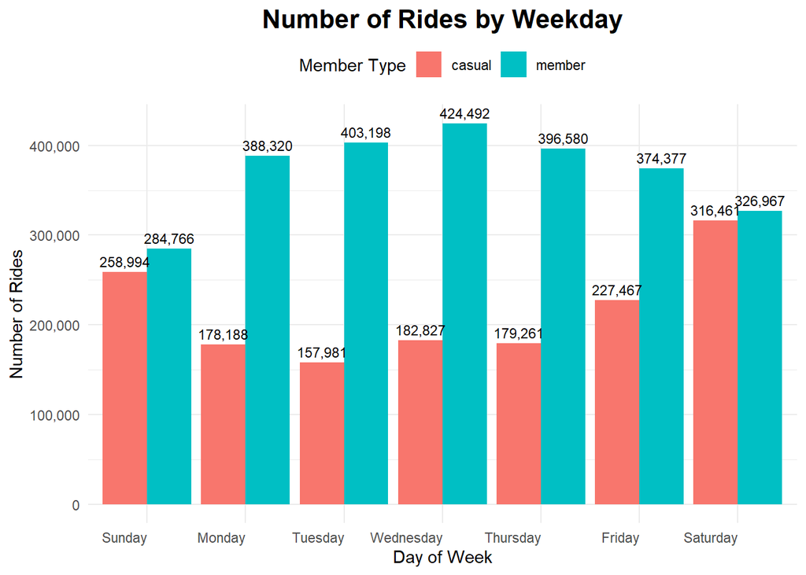

```r
#order the days of the week ensuring the days are listed in order from Sunday to Saturday

day_order <- c("Sunday", "Monday", "Tuesday", "Wednesday", "Thursday", "Friday", "Saturday")

# Number of rides by day of the week
####
ride_by_weekday <- Divvy_12_Months_data %>%
  mutate(day_of_week = factor(day_of_week, levels = day_order)) %>%
  group_by(user_type, day_of_week) %>%
  summarise(number_of_rides = n(), .groups = "drop") %>%
  ggplot(aes(x = day_of_week, y = number_of_rides, fill = user_type)) +
  geom_col(position = position_dodge(width = 0.9)) +
  geom_text(
    aes(label = comma(number_of_rides)),
    position = position_dodge(width = 0.9),
    vjust = -0.5,
    size = 3
  ) +
  scale_y_continuous(labels = comma) +
  labs(
    title = "Number of Rides by Weekday",
    x = "Day of Week",
    y = "Number of Rides",
    fill = "Member Type"
  ) +
  theme_minimal() +
  theme(
    plot.title = element_text(hjust = 0.5, size = 16, face = "bold"),
    plot.subtitle = element_text(hjust = 0.5),
    plot.caption = element_text(hjust = 0.5),
    legend.position = "top",
    legend.justification = "center",
    axis.text.x = element_text(angle = 0, hjust = 1))
# Display the plot
ride_by_weekday
```

#### **Average ride length by day of the week**

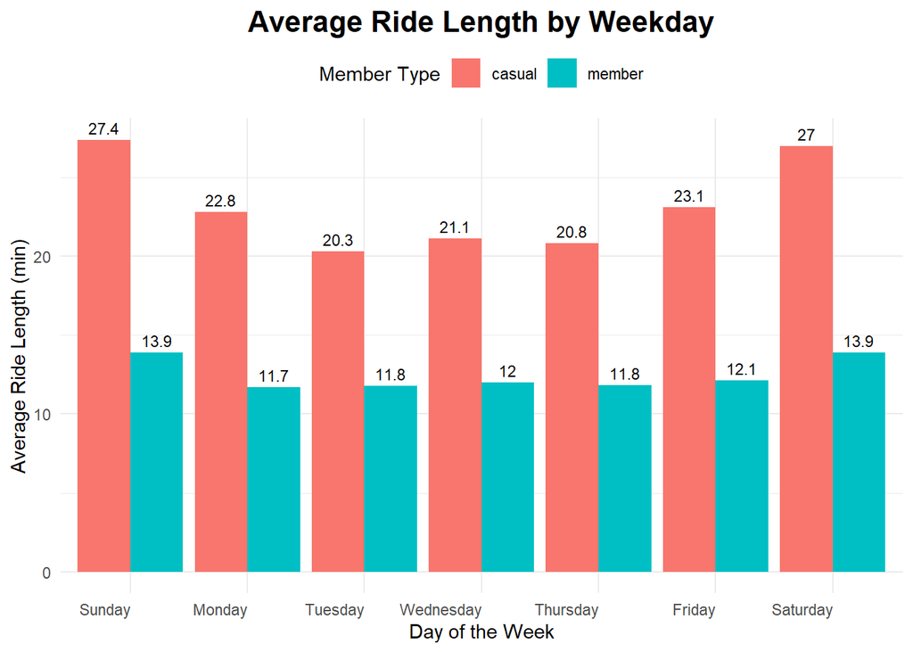

```r
#average ride length by day of the week
#####
Avg_ride_length_by_weekday <- Divvy_12_Months_data %>%
  mutate(day_of_week = factor(day_of_week, levels = day_order)) %>%
  group_by(user_type, day_of_week) %>%
  summarise(average_ride_length = mean(ride_length), .groups = "drop") %>%
  ggplot(aes(x = day_of_week, y = average_ride_length, fill = user_type)) +
  geom_col(position = position_dodge(width = 0.9)) +
  geom_text(
    aes(label = round(average_ride_length, 1)),  # or use comma(average_ride_length)
    position = position_dodge(width = 0.9),
    vjust = -0.5,
    size = 3
  ) +
  scale_y_continuous(labels = comma) +
  labs(
    title = "Average Ride Length by Weekday",
    x = "Day of the Week",
    y = "Average Ride Length (min)",
    fill = "Member Type"
  ) +
  theme_minimal() +
  theme(
    plot.title = element_text(hjust = 0.5, size = 16, face = "bold"),
    plot.subtitle = element_text(hjust = 0.5),
    plot.caption = element_text(hjust = 0.5),
    legend.position = "top",
    legend.justification = "center",
    axis.text.x = element_text(angle = 0, hjust = 1))
# Display the plot
Avg_ride_length_by_weekday
```

#### **Number of rides by types of bike**

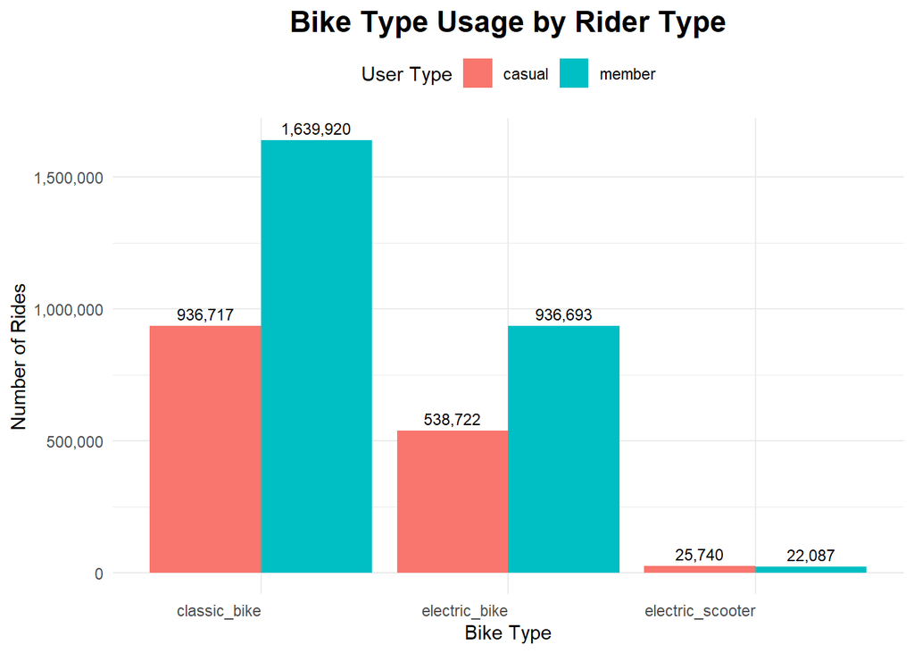

```r
#Number of rides by types of bike
####
rides_by_type_of_bike <- Divvy_12_Months_data %>%
  group_by(user_type, bike_type) %>%
  summarise(number_of_rides = n(), .groups = "drop") %>%
  ggplot(aes(x = bike_type, y = number_of_rides, fill = user_type)) +
  geom_col(position = position_dodge(width = 0.9)) +
  geom_text(
    aes(label = comma(number_of_rides)),
    position = position_dodge(width = 0.9),
    vjust = -0.5,
    size = 3
  ) +
  scale_y_continuous(labels = comma) +
  labs(
    title = "Bike Type Usage by Rider Type",
    x = "Bike Type",
    y = "Number of Rides",
    fill = "User Type"
  ) +
  theme_minimal() +
  theme(
    plot.title = element_text(hjust = 0.5, size = 16, face = "bold"),
    plot.subtitle = element_text(hjust = 0.5),
    plot.caption = element_text(hjust = 0.5),
    legend.position = "top",
    legend.justification = "center",
    axis.text.x = element_text(angle = 0, hjust = 1))
# Display the plot
rides_by_type_of_bike
```

#### **Rides per month by rider type**

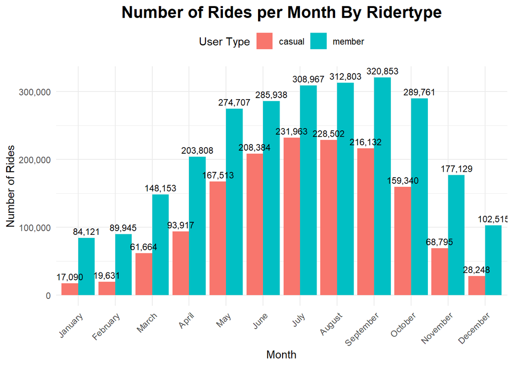

```r
# defining the month order

month_order <- c("January", "February", "March", "April", "May", "June", "July", "August", "September",
"October", "November", "December")

#Rides per month by rider type
###
rides_per_month_by_ridertype <- Divvy_12_Months_data %>%
  mutate(month = factor(month, levels = month_order)) %>%
  group_by(user_type, month) %>%
  summarise(number_of_rides = n(), .groups = "drop") %>%
  ggplot(aes(x = month, y = number_of_rides, fill = user_type)) +
  geom_col(position = position_dodge(width = 0.9)) +
  geom_text(
    aes(label = comma(number_of_rides)),
    position = position_dodge(width = 0.9),
    vjust = -0.5,
    size = 3
  ) +
  scale_y_continuous(labels = comma) +
  labs(
    title = "Number of Rides per Month By Ridertype",
    x = "Month",
    y = "Number of Rides",
    fill = "User Type"
  ) +
  theme_minimal() +
  theme(
    plot.title = element_text(hjust = 0.5, size = 16, face = "bold"),
    plot.subtitle = element_text(hjust = 0.5),
    plot.caption = element_text(hjust = 0.5),
    legend.position = "top",
    legend.justification = "center",
    axis.text.x = element_text(angle = 45, hjust = 1))
# Display the plot
rides_per_month_by_ridertype
```

#### **Top 10 Peak Usage Days for Casual Riders**

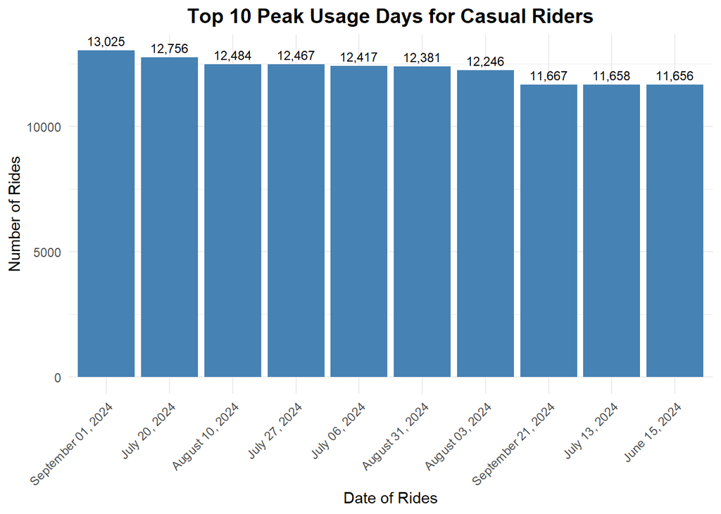

```r
# Step 1: Get daily ride counts for casual riders
casual_daily_counts <- Divvy_12_Months_data %>%
  filter(user_type == "casual") %>%
  group_by(date) %>%
  summarise(rides = n(), .groups = "drop")

# Step 2: Get top 10 highest-usage days
top_10_dates <- casual_daily_counts %>%
  arrange(desc(rides)) %>%
  slice_head(n = 10) %>%
  mutate(date_label = format(date, "%B %d, %Y"))  # for cleaner x-axis labels

# Step 3: Bar chart with labels and rotated x-axis
ggplot(top_10_dates, aes(x = reorder(date_label, -rides), y = rides)) +
  geom_col(fill = "steelblue") +
  geom_text(
    aes(label = scales::comma(rides)),
    vjust = -0.5,
    size = 3
  ) +
  labs(
    title = "Top 10 Peak Usage Days for Casual Riders",
    x = "Date of Rides",
    y = "Number of Rides"
  ) +
  theme_minimal() +
  theme(
    axis.text.x = element_text(angle = 45, hjust = 1),
    plot.title = element_text(hjust = 0.5, size = 14, face = "bold")
  )
```

### **6. Acting on the findings of the analysis**

#### **Recommendations**

**1. Target casual riders with weekday commuter incentives** Insight: Casual riders take longer rides mostly on weekends, while members ride shorter distances but more consistently on weekdays.

- Promote the time and cost savings of membership for daily use.
- Launch campaigns encouraging casual riders to try weekday commuting

**2. Offer seasonal promotions or loyalty discounts to casual riders** Insight: Casual ridership spikes in summer months between June and September, while members ride more evenly year round. - Especially during the months when casual ridership is highest. - Tailor messages around recreational convenience plus long-term savings.

#### **Conclusion**:

There are clear behavioral distinctions between casual and member riders. Members show consistent, short-duration, weekday usage — typical of commuter habits. Casual riders exhibit longer, leisure-style rides that spike on weekends and in summer. These insights provide a strong foundation for marketing strategies targeting casual-to-member conversion.